# P4 - Análise Exploratória de Dados

20 de novembro, 2017

## Reclamações de Consumidores Brasileiros em Janeiro de 2015

Este projeto consiste na análise das reclamações de consumidores brasileiros registradas no site Consumidor.gov.br e que foram finalizadas em Janeiro de 2015. Esta base de dados foi adquirida no Portal Brasileiro de Dados Abertos, o dados.org, juntamente com um dicionário que explica suas variáveis. A estrutura da base de dados é mostrada na tabela abaixo.

```
## Classes 'data.table' and 'data.frame':   8619 obs. of  24 variables:
##  $ Região                : chr  "CO" "CO" "S" "SE" ...
##  $ UF                    : chr  "DF" "DF" "RS" "SP" ...
##  $ Cidade                : chr  "Brasília" "Brasília" "Porto Alegre" "São Paulo" ...
##  $ Sexo                  : chr  "M" "M" "F" "M" ...
##  $ Faixa Etária          : chr  "entre 21 a 30 anos" "entre 41 a 50 anos" "entre 21 a 30 anos" "entre 21 a 30 anos" ...
##  $ Ano Abertura          : int  2014 2014 2014 2014 2014 2014 2014 2014 2014 2014 ...
##  $ Mês Abertura          : int  11 11 11 11 11 12 12 12 12 12 ...
##  $ Data Abertura         : chr  "28/11/2014" "27/11/2014" "26/11/2014" "20/11/2014" ...
##  $ Data Resposta         : chr  "15/12/2014" "15/12/2014" "16/12/2014" "12/12/2014" ...
##  $ Data Finalização      : chr  "02/01/2015" "05/01/2015" "06/01/2015" "02/01/2015" ...
##  $ Tempo Resposta        : int  10 10 9 9 9 10 5 7 10 10 ...
##  $ Nome Fantasia         : chr  "Banco do Brasil" "Itaú BMG Consignado" "GVT" "Tim" ...
##  $ Segmento de Mercado   : chr  "Bancos, Financeiras e Administradoras de Cartão" "Bancos, Financeiras e Administradoras de Cartão" "Operadoras de Telecomunicações (Telefonia, Internet, TV por assinatura)" "Operadoras de Telecomunicações (Telefonia, Internet, TV por assinatura)" ...
##  $ Área                  : chr  "Serviços Financeiros" "Serviços Financeiros" "Telecomunicações" "Telecomunicações" ...
##  $ Assunto               : chr  "Serviço de pagamento online/ via celular" "Crédito Consignado (Empréstimo descontado em folha de pagamento)" "Pacote de Serviços ( Combo )" "Serviços na internet (provedor, hospedagem, antivírus, vídeos online, aplicativos, jogos)" ...
##  $ Grupo Problema        : chr  "Cobrança / Contestação" "Atendimento / SAC" "Vício de Qualidade" "Informação" ...
##  $ Problema              : chr  "Dificuldade na devolução de valores pagos / reembolso / retenção de valores" "SAC - Demanda não resolvida / não respondida" "Funcionamento inadequado do serviço (má qualidade do sinal, instabilidade, queda)" "Informações incompletas / inadequadas sobre o serviço, …
##  $ Como Comprou Contratou: chr  "Internet" "Telefone" "Telefone" "Internet" ...
##  $ Procurou Empresa      : chr  "S" "S" "S" "S" ...
##  $ Respondida            : chr  "S" "S" "S" "S" ...
##  $ Situação              : chr  "Finalizada avaliada" "Finalizada não avaliada" "Finalizada não avaliada" "Finalizada não avaliada" ...
##  $ Avaliação Reclamação  : chr  "Não Resolvida" "Não Avaliada" "Não Avaliada" "Não Avaliada" ...
##  $ Nota do Consumidor    : int  1 NA NA NA NA 5 5 NA NA 1 ...
##  $ newUF                 : chr  "Distrito Federal" "Distrito Federal" "Rio Grande do Sul" "São Paulo" ...
##  - attr(*, ".internal.selfref")=<externalptr>
```

A base de dados possui 8619 reclamações e 24 variáveis.

### Seção de gráficos univariados

Quem reclama mais, homens ou mulheres?

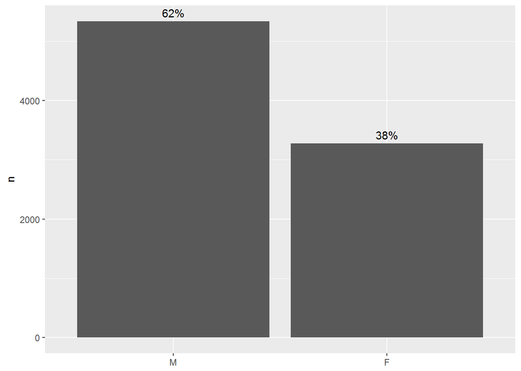

Qual é a distribuição das reclamações pelas faixas etárias?

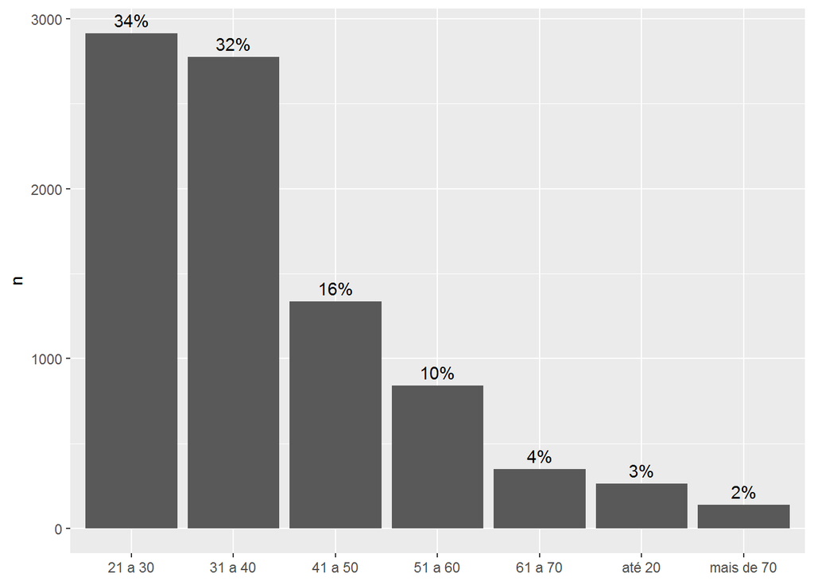

Quais são os Segmentos de Mercado com maior número de reclamações?

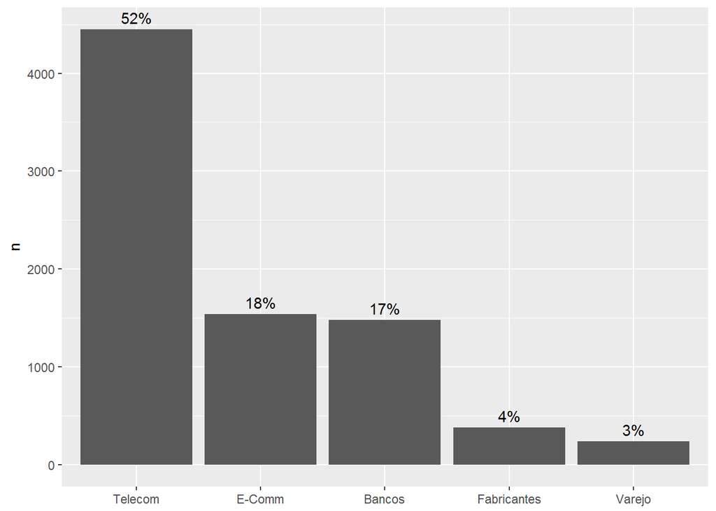

Aqui foram mostrados apenas os cinco Segmentos de Mercado com maior número de reclamações para facilitar a visualização. Telecomunicações, Comércio Eletrônico e Bancos somam 87% de todas as reclamações.

Quais são os grupos de problema mais frequentes nas reclamações?

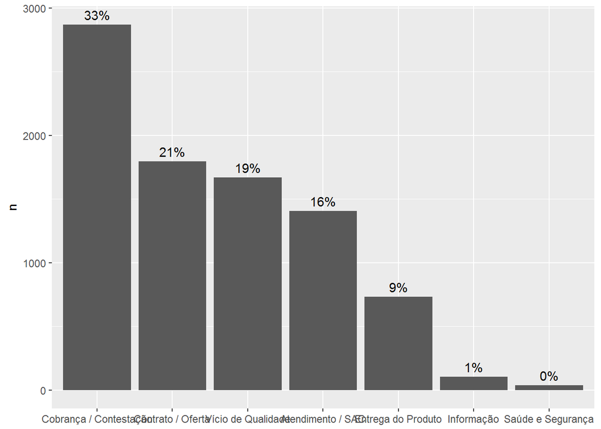

Qual é a proporção de reclamações resolvidas? Obs: Para responder esta pergunta, foi utilizado o mesmo critério descrito no dicionário de variáveis. Verificou-se os valores contidos na coluna ‘Avaliação Reclamação’ e os valores ‘resolvida’ e ‘não avaliada’ foram associados à 1 em uma coluna chamada ‘Resolvida’. Já os valores iguais a ‘não resolvida’ foram associados à 0.

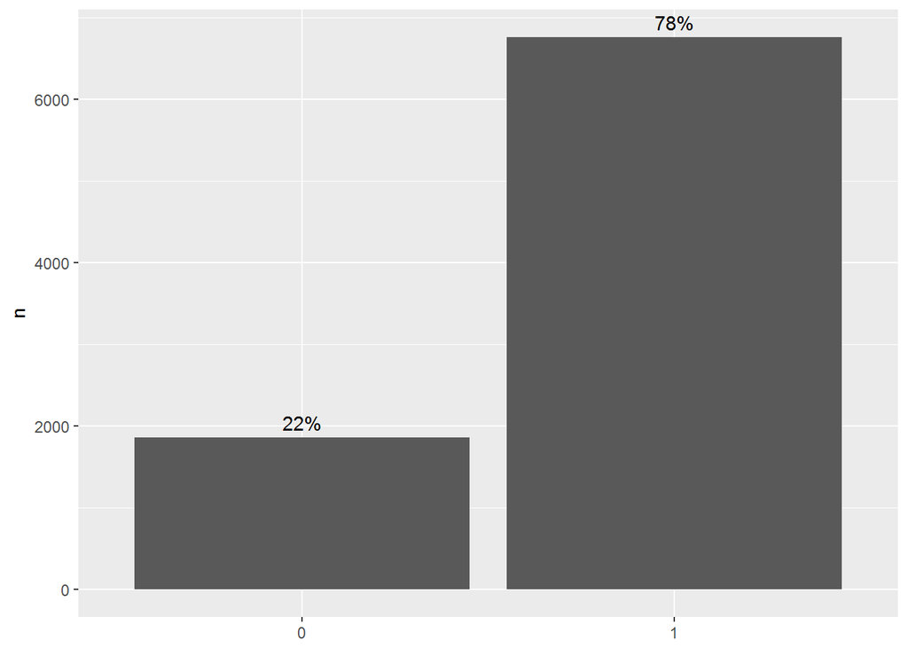

Considerando a coluna ‘Avaliação Reclamação’, qual é a porcentagem das reclamações não avaliadas?

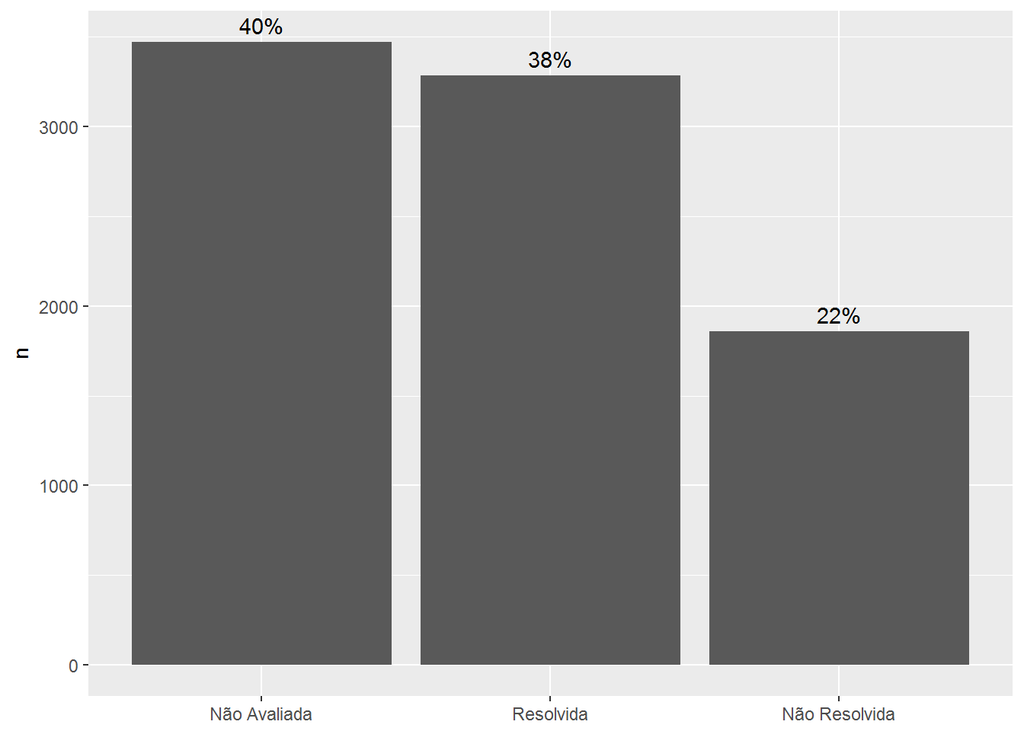

Existem muitas reclamações não respondidas?

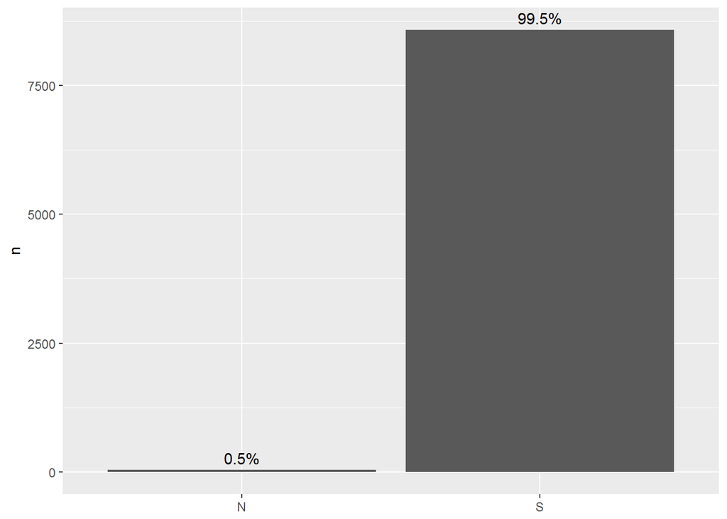

Sabe-se que as empresas tem um prazo máximo de 10 dias para responder as reclamações feitas. Qual é a distribuição das reclamações por estes 10 dias?

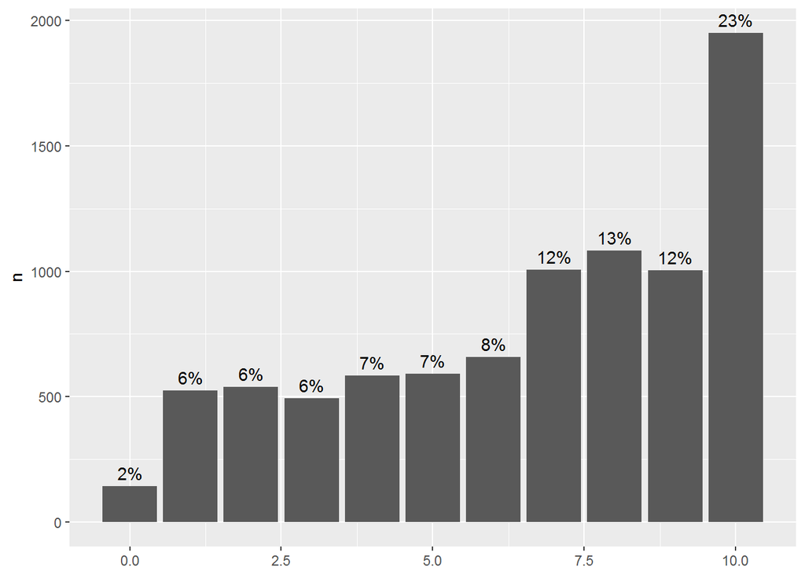

Nota-se que a proporção é crescente conforme aumentam-se os dias. Mas qual é o tempo médio de resposta?

```
## [1] 6.596923
```

A tempo médio de resposta é de aproximadamente 6,6 dias.

Sabe-se que os consumidores, ao avaliarem a empresa, dão uma nota de 1 à 5. Qual é a distribuição das avaliações por estas notas?

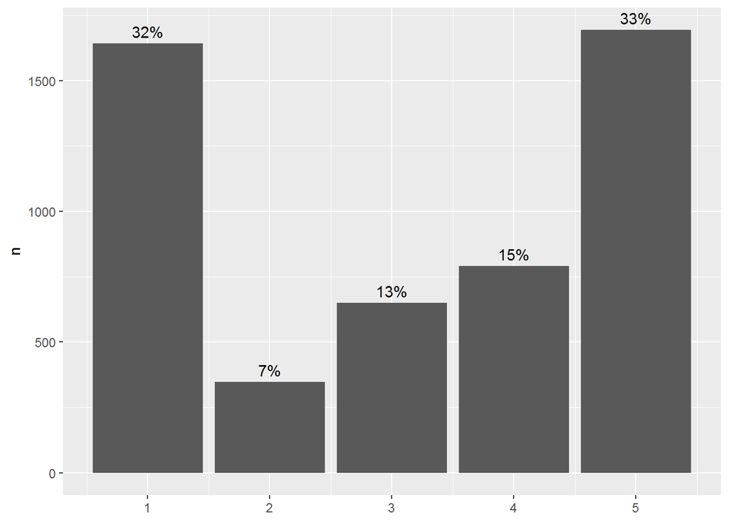

Nota-se que as notas mínima e máxima são as mais representativas. Qual é a nota média?

```
## [1] 3.100253
```

A nota média dada às reclamações é 3,1.

Qual é a distribuição das reclamações pelos estados brasileiros?

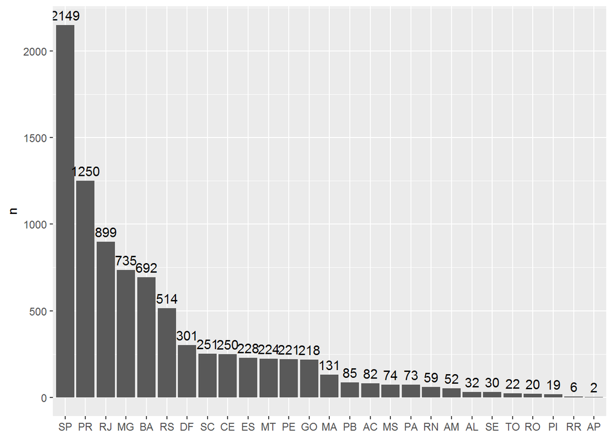

Quais são as empresas com maior número de reclamações?

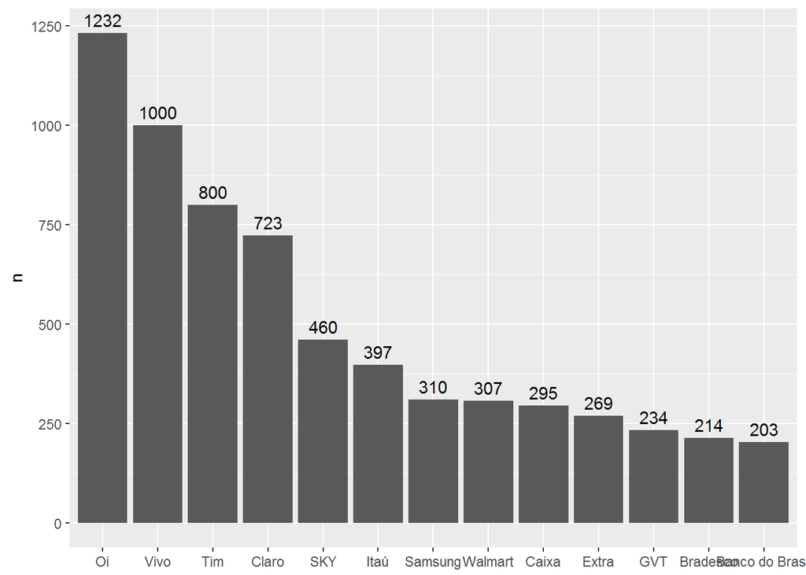

Foram mostradas apenas as empresas com mais de duzentas reclamações.

### Seção de Gráficos Bivariados

Nesta seção, a fim de melhorar a visualização, serão filtrados os principais segmentos de mercado. Qual é o perfil dos reclamantes?

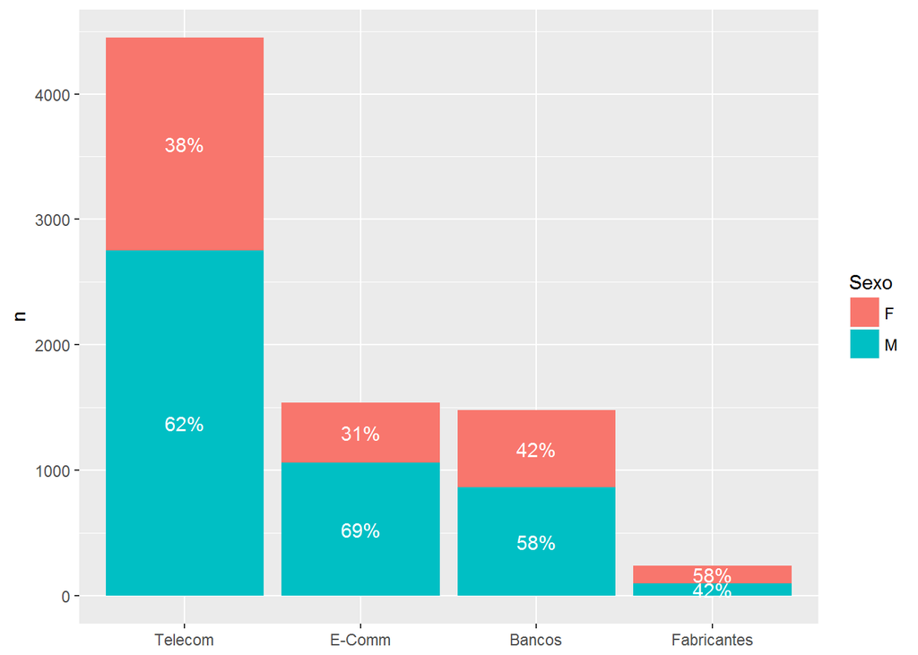

O sexo dos reclamantes é majoritariamente masculino em três dos quatro principais segmentos de mercado.

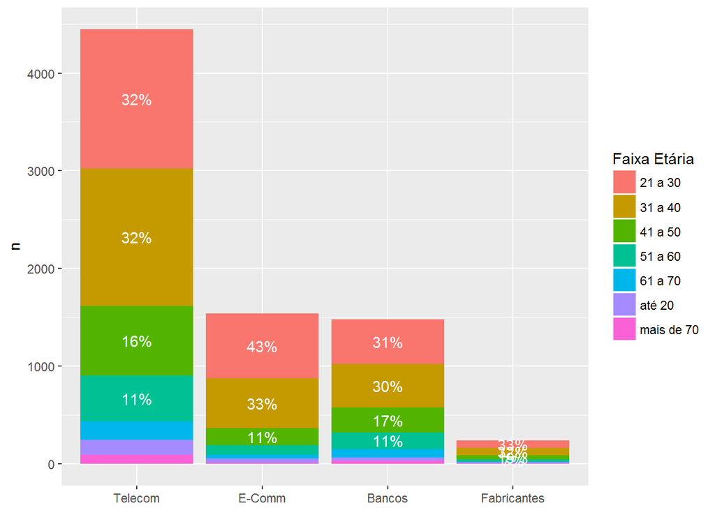

Em todos os segmentos de mercado a maioria dos reclamantes se concentra nas faixas de 21 a 30 anos e 31 a 40 anos, mas no segmento de comércio eletrônico, percebe-se que a faixa de 21 a 30 anos tem a frequência relativa maior em relação aos demais. Isso pode indicar que o público do comércio eletrônico é mais jovem, ou que o público mais velho prefere comprar nas lojas físicas.

Há diferença na distribuição de notas pelas faixas etárias e sexo?

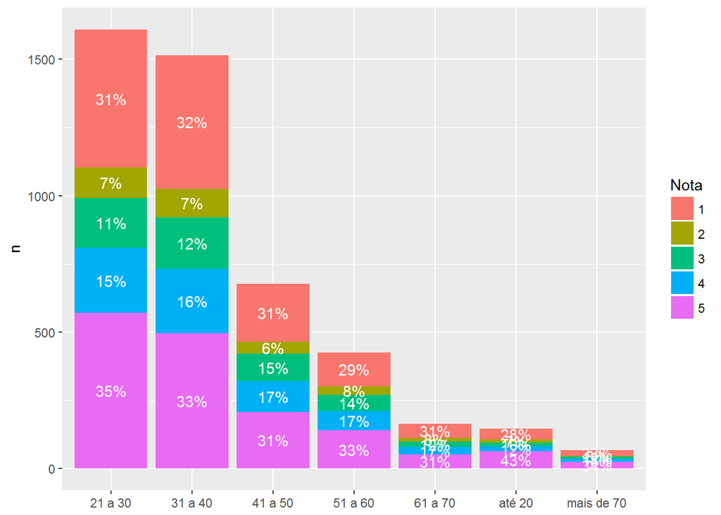

Com exceção da faixa até 20 anos, que apresenta maior frequência relativa nas notas 5, observa-se que as frequências não se diferem muito nas diferentes faixas etárias.

### Correlações

Existe correlação entre o tempo de resposta e a nota do consumidor? Será que as reclamações resolvidas mais rapidamente ganham notas maiores?

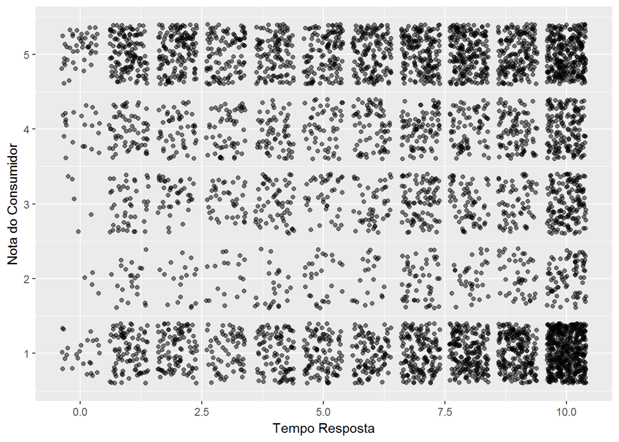

```
## [1] 0.01004737
```

O resultado do teste de correlação é 0,01, ou seja, não existe correlação entre tempo de resposta e a nota. Como já visto anteriormente, a quantidade de reclamações resolvidas é crescente até o dia limite para a resposta. Este gráfico deixa a impressão de que as notas 5 estão mais bem distribuídas pelos dias do tempo de resposta, enquanto as notas 1 estão mais concentradas no décimo dia. Para confirmar, utilizar-se-á um diagrama de caixa.

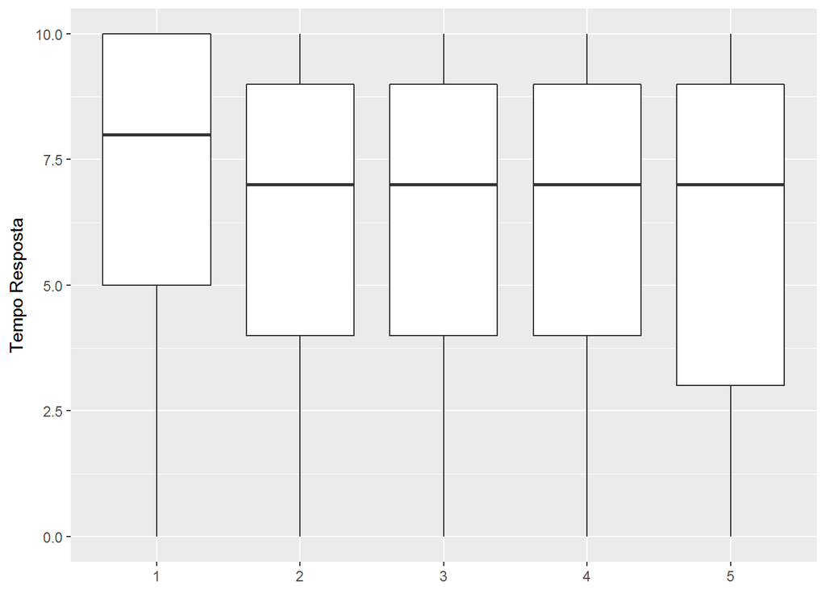

Nota-se que a mediana da caixa das notas 1 se encontra maior do que as demais caixas e o corpo da caixa das notas 5 começa um pouco abaixo das demais. Isto significa que, apesar de não haver correlação entre tempo de resposta e nota, as reclamações de nota igual à 1 apresentam tempos de resposta ligeiramente maiores que as demais e as reclamações de nota igual à 5 apresenta tempos de resposta ligeiramente menores que as demais.

Tempo médio de resposta por nota

| Nota do Consumidor | media |
| --- | --- |
| 1 | 6.977480 |
| 2 | 6.672414 |
| 3 | 6.497696 |
| 4 | 6.229114 |
| 5 | 6.048997 |

A tabela acima confirma as análises feitas anteriormente.

Existe correlação entre a nota do consumidor e se a reclamação foi resolvida ou não?

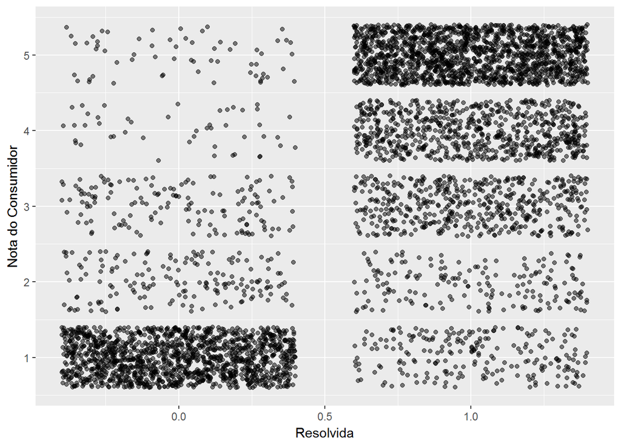

```
## [1] 0.7345444
```

O resultado do teste de correlação é 0,73, o que demonstra que existe forte correlação entre a avaliação da reclamação e a nota do consumidor. A grande maioria das reclamações não resolvidas receberam nota igual a 1 enquanto as reclamações resolvidas receberam, em sua maioria, notas acima de 3.

Como observado anteriormente, quase 90% de todas as reclamações se concentram em três segmentos: Telecomunicações, Comércio Eletrônico e Bancos. Por isso, esses segmentos serão destacados dos demais. Quais são os grupos de problemas mais frequêntes nos três segmentos de maior número de reclamações?

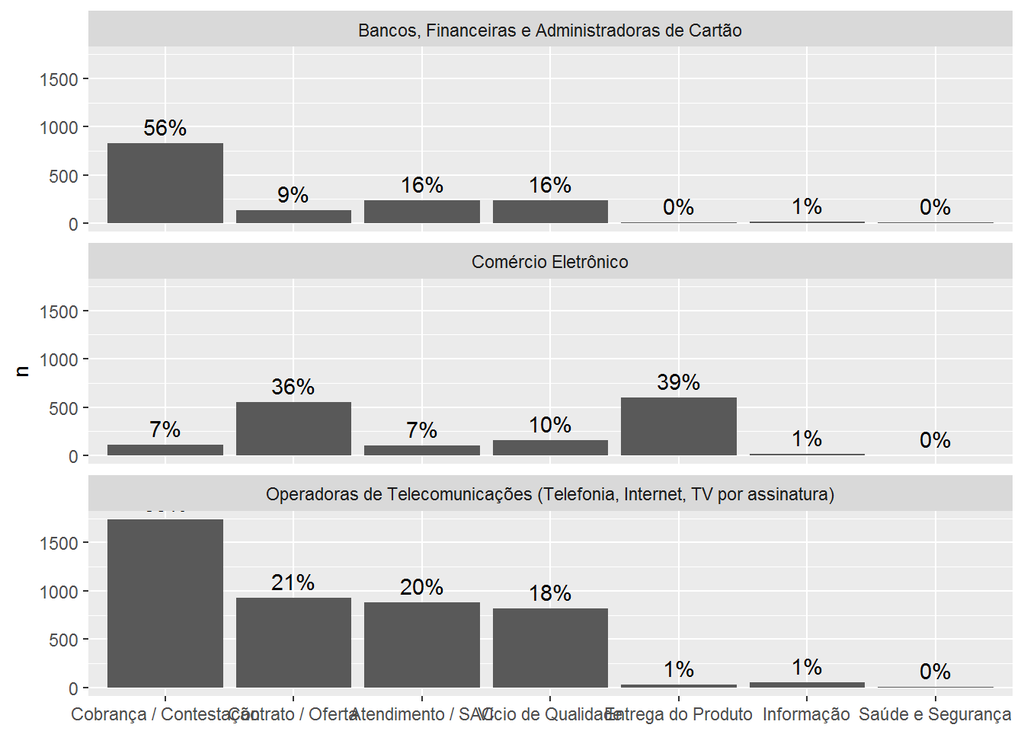

Mas o que cada um desses grupos representa?

Tabela de Problemas

| Grupo Problema | Problema | n |
| --- | --- | --- |
| Contrato / Oferta | Oferta não cumprida / serviço não fornecido/ venda enganosa / publicidade enganosa | 1055 |
| Cobrança / Contestação | Cobrança por serviço/produto não contratado / não reconhecido / não solicitado | 822 |
| Entrega do Produto | Não entrega / demora na entrega do produto | 534 |
| Vício de Qualidade | Funcionamento inadequado do serviço (má qualidade do sinal, instabilidade, queda) | 490 |
| Atendimento / SAC | SAC - Demanda não resolvida / não respondida | 477 |
| Cobrança / Contestação | Dificuldade na devolução de valores pagos / reembolso / retenção de valores | 283 |
| Cobrança / Contestação | Cobrança por serviço não fornecido/ em desacordo com a utilização / fora do prazo | 281 |
| Cobrança / Contestação | Cobrança após cancelamento do serviço | 263 |
| Cobrança / Contestação | Cobrança em duplicidade / Cobrança referente a pagamento já efetuado | 188 |
| Atendimento / SAC | Má qualidade no atendimento presencial ou outros canais (mau atendimento/ constrangimento) | 177 |
| Cobrança / Contestação | Cobrança de tarifas, taxas, valores não previstos / não informados | 162 |
| Cobrança / Contestação | Dificuldade na Renegociação / parcelamento de dívida | 161 |
| Atendimento / SAC | SAC - Dificuldade para cancelar o serviço | 142 |
| Atendimento / SAC | Dificuldade de contato / demora no atendimento | 136 |
| Contrato / Oferta | Alteração de plano/contrato sem solicitação ou aviso prévio | 136 |
| Vício de Qualidade | Produto danificado / não funciona - Dificuldade em trocar ou consertar no prazo de garantia | 136 |
| Vício de Qualidade | Suspensão ou desligamento indevido do serviço | 117 |
| Atendimento / SAC | SAC - Dificuldadede de contato / acesso | 114 |
| Vício de Qualidade | Dificuldade para alterar/ ativar serviços | 107 |
| Atendimento / SAC | Má qualidade no atendimento (descortesia / despreparo/ constrangimento) | 100 |
| Cobrança / Contestação | Cálculo de juros, saldo devedor (contestação, solicitação de histórico, dúvidas) | 100 |
| Contrato / Oferta | Dificuldade para contratar / recusa injustificada | 97 |
| Cobrança / Contestação | Negativação indevida | 85 |
| Entrega do Produto | Produto entregue incompleto / diferente do pedido | 80 |
| Vício de Qualidade | Portabilidade não efetivada | 74 |
| Contrato / Oferta | Dificuldade para rescindir o contrato / cancelar o serviço | 64 |
| Atendimento / SAC | SAC - Descortesia / despreparo / demora | 58 |
| Cobrança / Contestação | Cobrança submetendo a ofensa, constrangimento ou ameaça | 57 |
| Contrato / Oferta | Serviço indisponível para a região ou sem previsão | 57 |
| Vício de Qualidade | Não envio / atraso do boleto ou fatura / dificuldade com o pagamento | 57 |

[output cut: 58 more lines]

Relacionando a tabela e o gráfico acima, percebe-se uma concentração de problemas relacionados a Cobrança no segmento ‘Bancos’, indicando que os consumidores deste segmento sofrem com cobranças de serviços não contratados, não fornecidos, cobranças após o cancelamento e etc. No segmento ‘Comércio eletrônico’, as reclamações estão bastante concentradas nos grupos Contrato e Entrega do Produto, indicando que os consumidores se queixam de ofertas não cumpridas, venda enganosa, demora na entrega do produto, não entrega do produto, produto entregue danificado, entre outros. Já para o segmento ‘Telecomunicações’, observa-se que há um pico no grupo ‘Cobranças’, mas também há uma boa concentração de reclamações nos grupos ‘Contrato’, ‘Atendimento’ e ‘Vício de qualidade’, indicando que os consumidores deste segmento sofrem com vários tipos de problema, incluindo cobranças indevidas, serviços não fornecidos, venda enganosa, má qualidade do serviço e problemas com atendimento.

### Seção de Gráficos Multivariados

Dos segmentos de mercado mais importantes, como estão distribuídos os reclamantes por sexo e faixa etária?

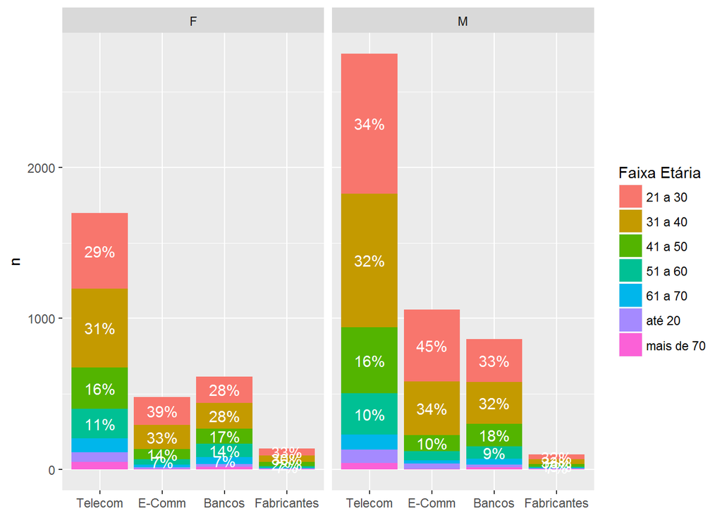

Como visto anteriormente, a maioria dos reclamantes se concentra nas faixas de 21 a 30 anos e 31 a 40 anos e os homens reclamam relativamente mais do que as mulheres. Observa-se a maior participação de pessoas entre 21 a 30 anos no segmento comércio eletrônico em ambos sexos, porém o sexo masculino é predominante neste segmento, com quase 70% das ocorrências.

Há diferença na distribuição de notas pelas faixas etárias e sexo?

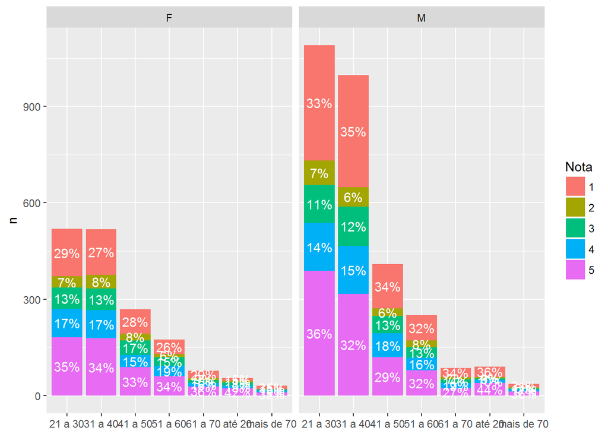

Percebe-se que os homens tem uma proporção maior de notas 1 em relação às mulheres, e proporções ligeiramente menores de notas 3 e 4. As proporções de notas 5, são relativamente constantes, com exceção da faixa etária de até 20 anos.

Qual é a proporção das reclamações resolvidas e não resolvidas por tempo de resposta e nota?

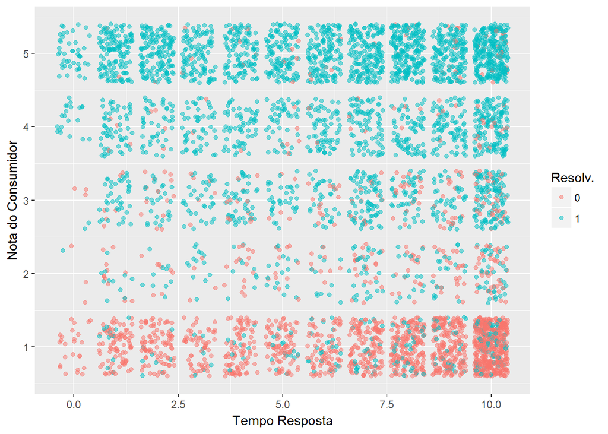

Nota média por Resolvida S/N

| Resolvida | media |
| --- | --- |
| 0 | 1.462039 |
| 1 | 4.029860 |

Tempo médio de resposta por S/N

| Resolvida | media |
| --- | --- |
| 0 | 6.906725 |
| 1 | 6.230347 |

Com o gráfico e as tabelas acima, percebemos que a diferença das notas entre as reclamações resolvidas e não resolvidas é muito significativa, o que não pode ser dito da diferença entre os tempos de resposta.

Qual é a distribuição das reclamações resolvidas e não resolvidas e das notas entre os segmentos?

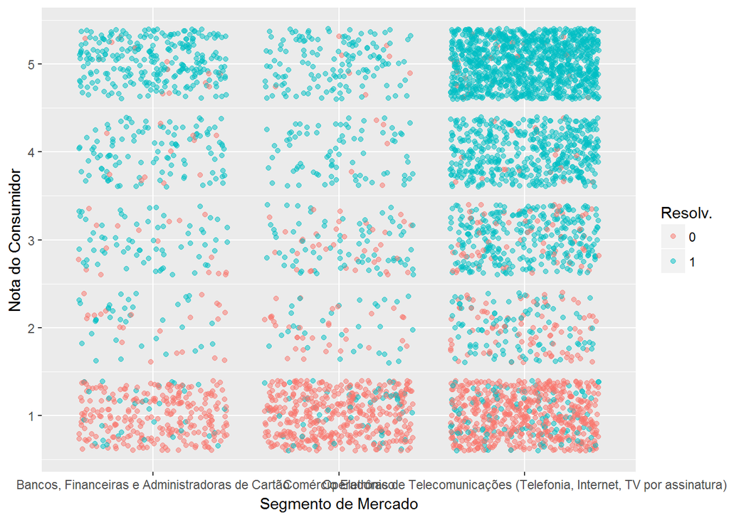

| Segmento de Mercado | resolvida | n_resolvida |
| --- | --- | --- |
| Bancos, Financeiras e Administradoras de Cartão | 4.043307 | 1.444795 |
| Comércio Eletrônico | 3.580214 | 1.313008 |
| Operadoras de Telecomunicações (Telefonia, Internet, TV por assinatura) | 4.102427 | 1.511502 |

Nota-se que o segmento de comércio eletrônico é o pior avaliado, com as menores médias de reclamações resolvidas e não resolvidas.

Qual é a distribuição das reclamações por grupo de problema, segmento de mercado e nota?

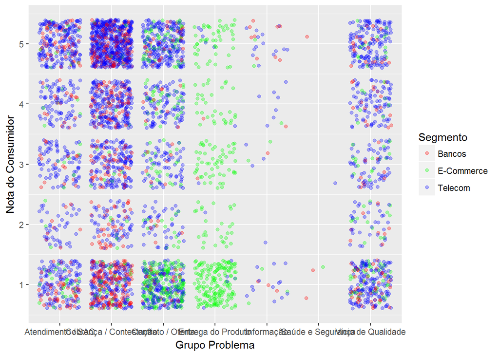

Percebe-se que o segmento comércio eletrônico é mal avaliado nos dois grupos de problema em que mais aparece. Telecomunicações parece ser mais bem avaliada em Cobrança do que no restante.

Notas médias por grupo de problema

| Segmento de Mercado | atendimento | cobranca | contrato | entrega | vicio |
| --- | --- | --- | --- | --- | --- |
| Bancos, Financeiras e Administradoras de Cartão | 3.156463 | 3.043750 | 3.225000 | 3.500000 | 2.626263 |
| Comércio Eletrônico | 2.576923 | 2.125000 | 2.254019 | 2.276786 | 2.393617 |
| Operadoras de Telecomunicações (Telefonia, Internet, TV por assinatura) | 3.374291 | 3.730598 | 3.176471 | 3.000000 | 3.078350 |

A tabela acima comprova a análise feita anteriormente.

Entre os Sexos e Faixas etárias, como estão distribuídas as notas?

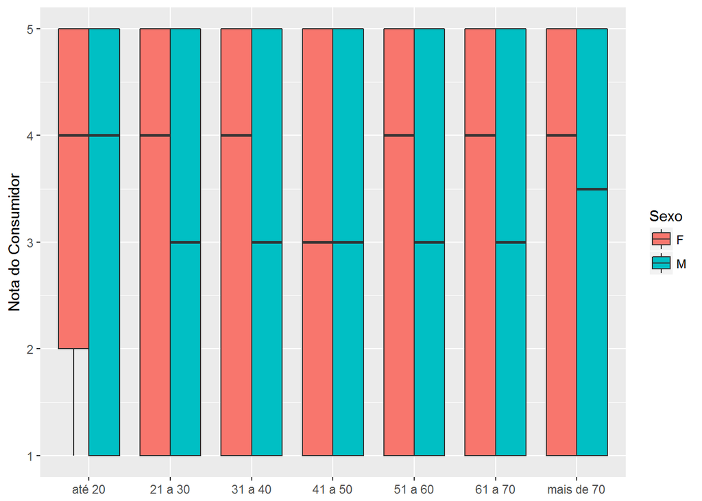

Reforçando as análises anteriores, nas quais vimos que os homens dão mais notas 1, percebe-se, aqui, que as medianas das caixas do sexo masculino estão abaixo ou em nível igual às medianas das caixas do sexo feminino. Como as notas de maiores proporções são as notas 1 e 5, o corpo das caixas geralmente começa na nota 1 e termina na nota 5.

Agora vamos analisar a fundo cada um dos segmentos, criando os índices apresentados no dicionário de variáveis.

### Telecomunicações

Índices

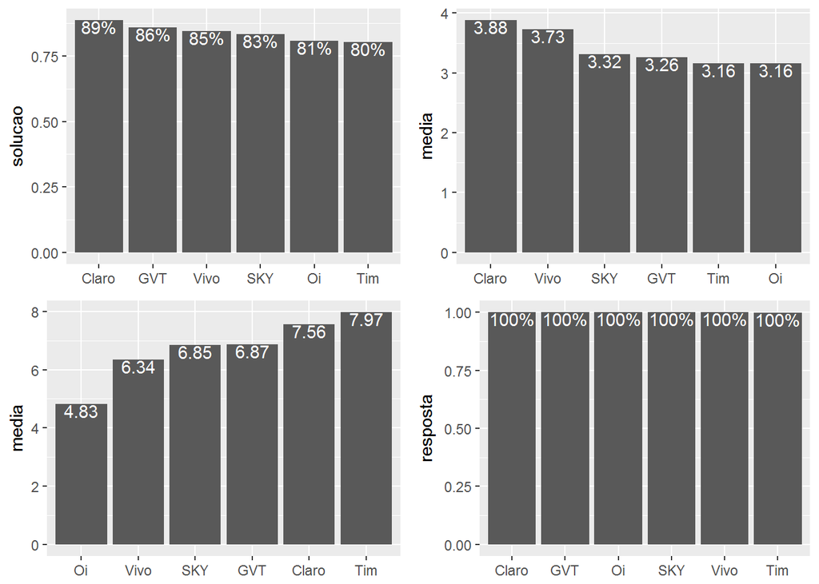

Nota-se que, como a nota e o índice de solução são correlacionados, a maior nota média é da Claro, a empresa que possui maior índice de solução. Já as piores notas médias são da Oi e da Tim, que possuem os piores índices de solução.

Grupos de Problema por Empresa

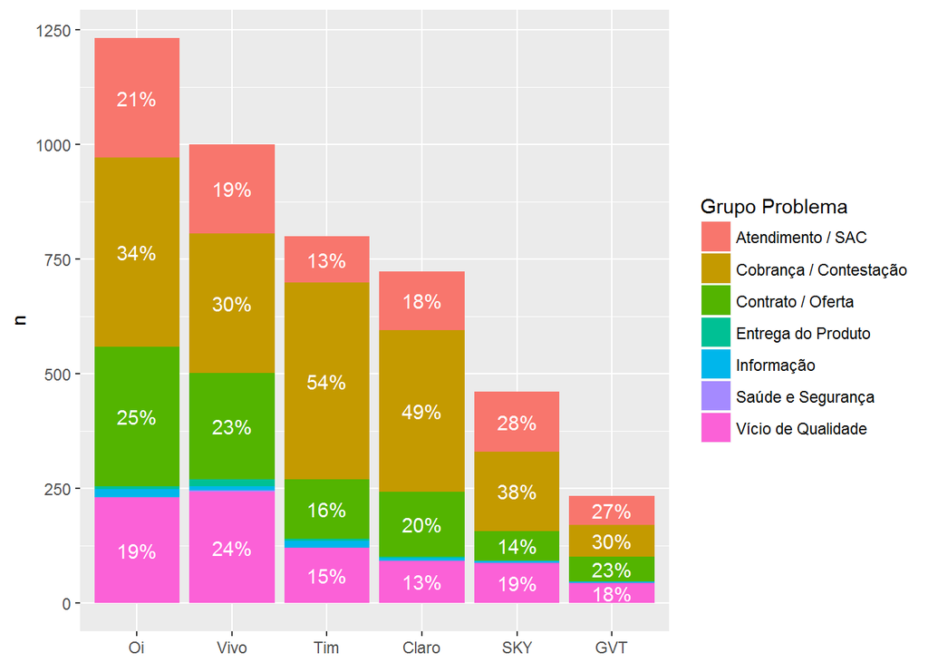

Observa-se que a Tim e a Claro apresentam maior concentração de reclamações no grupo ‘Cobrança’ enquanto a Oi e a Vivo apresentam problemas mais bem distribuídos.

Nota Média das Empresas por Estado

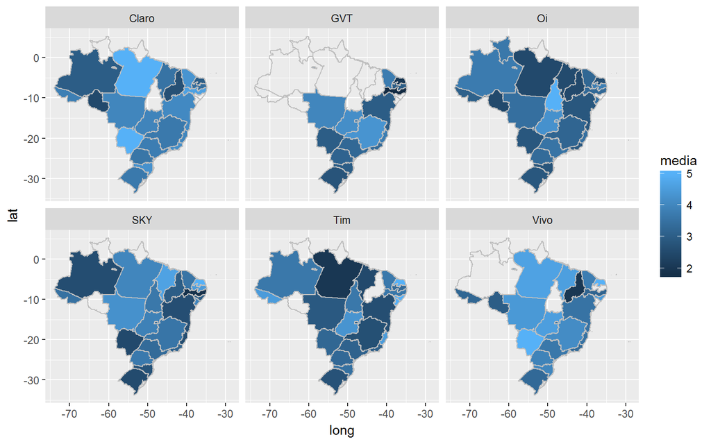

### Comércio Eletrônico

Índices

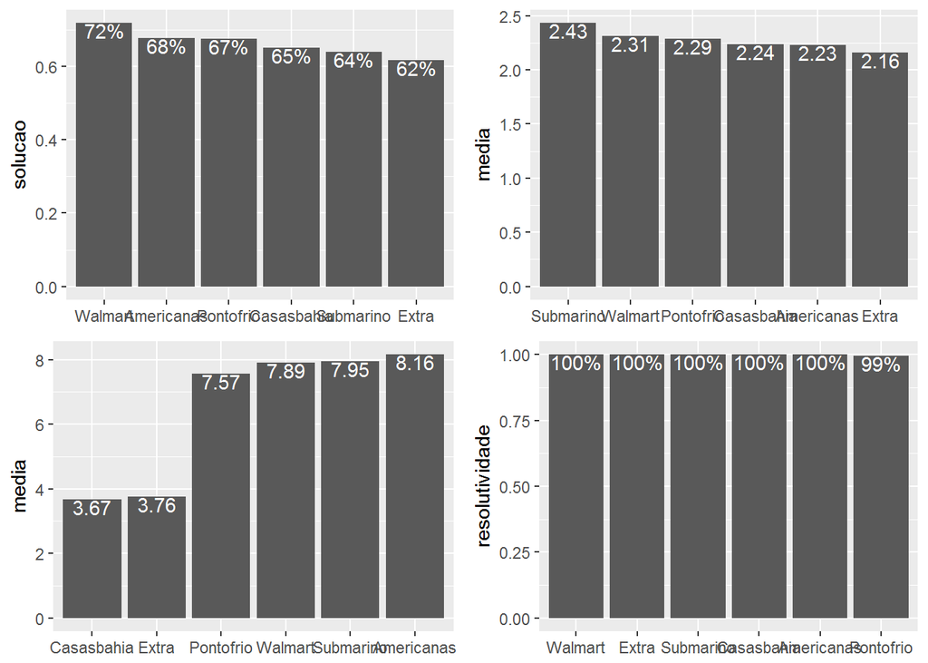

Aqui, percebe-se que, apesar da correlação entre nota e índice de solução, a empresa com a melhor nota é a Submarino, que é a quinta colocada no índice de solução. Percebe-se também que os índices de solução das empresas de comércio eletrônico (entre 62 e 72%) são bem menores em comparação com as empresas de Telecomunicações(entre 80 e 89%), impactando diretamente nas médias das notas destas.

Grupos de Problema por Empresa

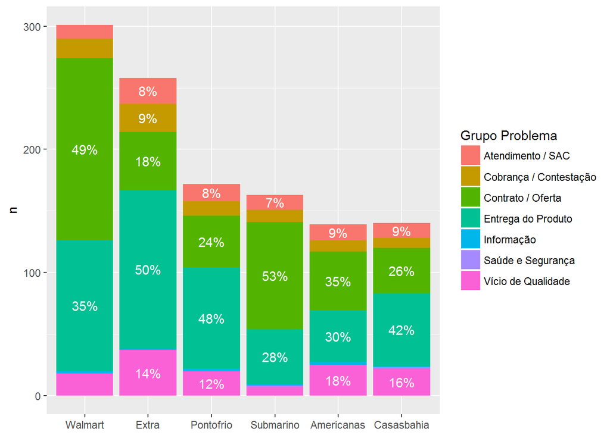

Nota Média das Empresas por Estado

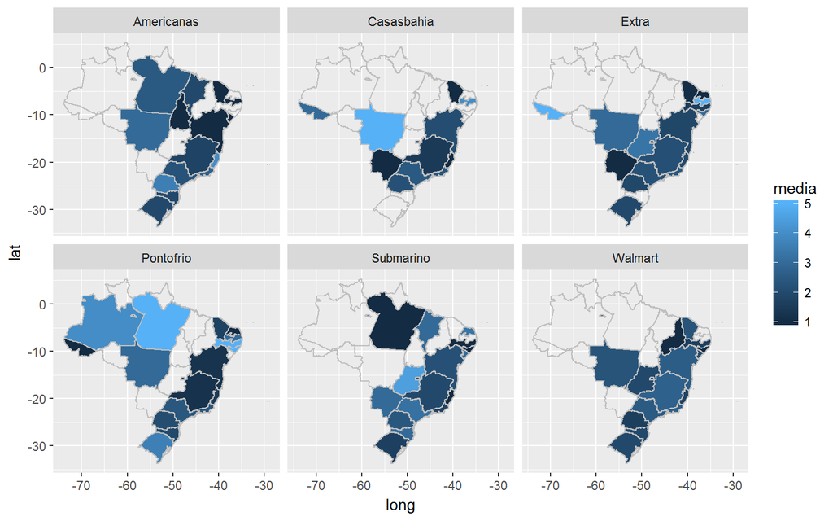